# CDC Health

WADDS

January 31, 2018

## Purpose

In this report, we aim to use information from the CDC Health dataset in order to answer the following question: what are the primary factors that affect a person’s general health?

This is an important question because, with our results, we will be able to determine which actions people can take or refrain from that will have the most effect on improving overall health. Additionally, this may help those who work in the health industry better predict which individuals will be in better health and which individuals may need more help in the future based on certain characteristics.

## Analysis

### General Health and Weight

In order to analyze the relationship between general health and weight, we made boxplots of the weight distributions for each category of general health, along with separating the data between men and women, since men tend to weight more than females. The results are shown below.

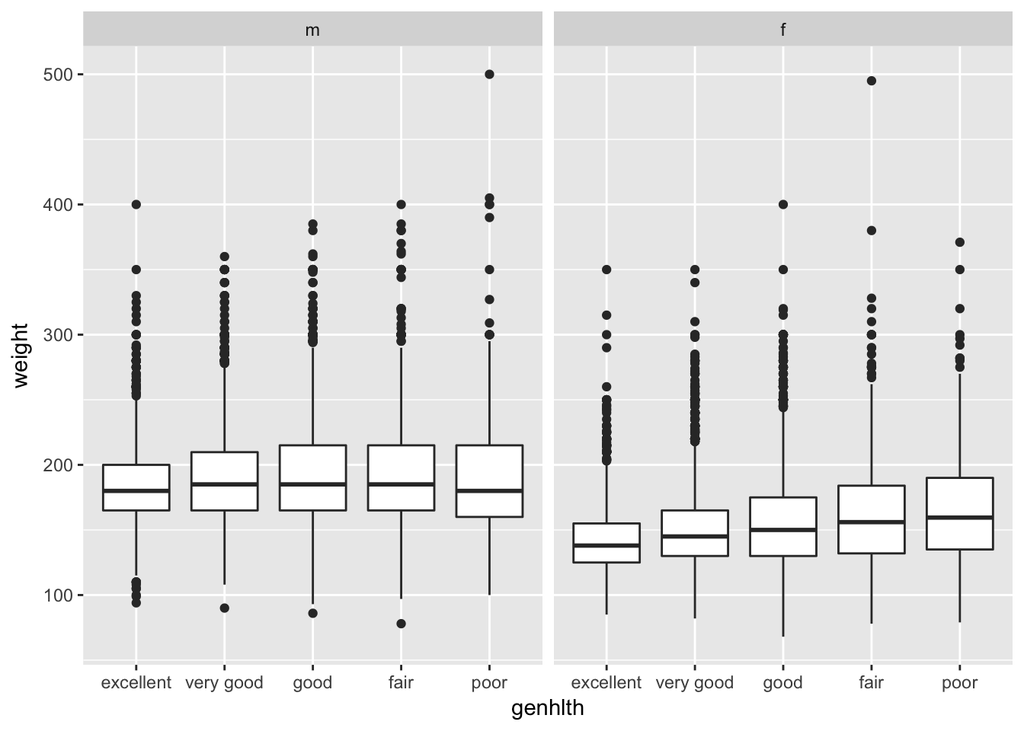

```r
ggplot(data=cdc)+geom_boxplot(aes(x=genhlth,y=weight))+facet_wrap(~gender)
```

Based on these plots, there doesn’t seem to be a significant relationship between weight and general health, surprisingly. With the exception of a couple of outliers, the median weight for men remains similar for each health category. For women, the median weight is slightly higher for each decreasing rating of health, but the minimum and maximum weight for each category and gender is around the same value, with the exception of a few outliers. This would indicate that weight doesn’t have much of an impact for general health for men, and for women, a higher weight has slight negative consequences for general health.

However, based on these findings, it seems like more research must be done to investigate general health, as weight does not seem like the most important factor.

With diseases becoming increasingly hard to fight off both with and without medication, it is interesting to see if the presence of healthcare has an effect on a person’s overall health. We would expect to find that people with healthcare are generally healthier than those without healthcare.

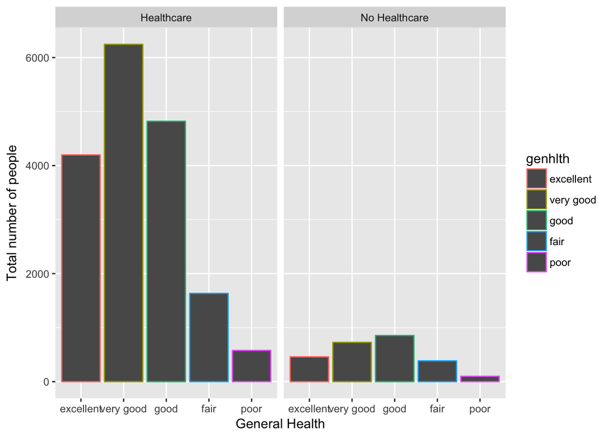

```r
ggplot(data=cdc,aes(genhlth,color=genhlth))+stat_count()+facet_wrap(~ifelse(hlthplan,"Healthcare", "No Healthcare"))+labs(x="General Health",y="Total number of people")
```

From the graphs we can see people with healthcare are generally healthier than people without healthcare. Among people with healthcare most people are in excellent or very good health. While among those without healthcare most people are only in very good or good health. This illustrates a slightly lower quality of health among people who do not have healthcare compared to the people who do.

Since there is not a huge difference between the health of those with healthcare and those without, it does not seem as though healthcare is the biggest indicator of a person’s overall health. Not accounted for in this analysis is the quality of healthcare provided, and how often it is utilized. With the given data it seems as though healthcare has a minimal effect on a person’s overall health.

In order to analyze our research question, we have make graph for the age and weight distribution along with separating the data between men and women, and also seperate group as people who have smoke more than 100 cigarettes and who have smoke fewer than 100 cigarettes. The results are shown below.

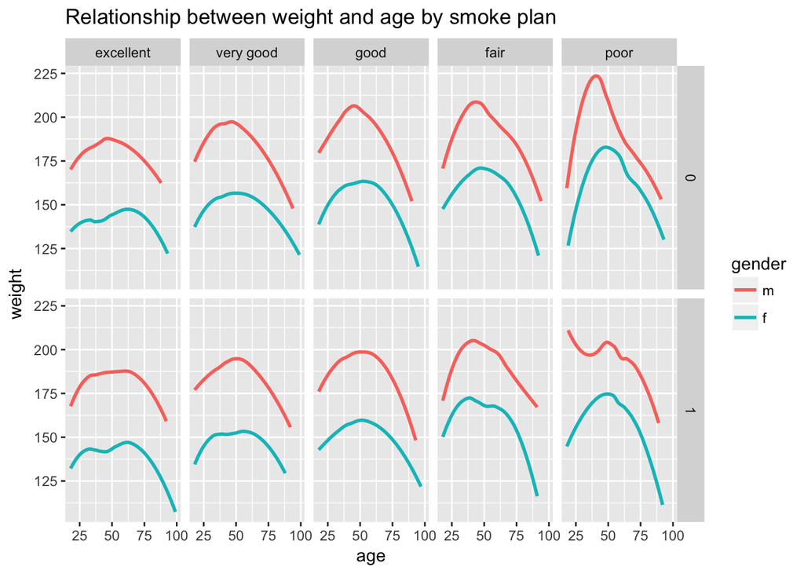

Based on what we have got for this graph, we have set up age as x-axis and weight as y-axis, and we have divided into groups as heavy smoking and light smoking group. Also we have denoted the blue color as female and red color as male group. If we see the people who smoke more than 100 cigarettes, people with higher weight and older age would have bad health condition, and for middle-age group(around 50 years old). If they have too much weight, and it’s easily to see that they have more health problem than young’s. As we have seen in another group, people with excellent condition might have fewer weight than others. However, based on these findings, it seems like more research must be done to investigate general health, not just smoking.

I’m interested in the specific question that how the weight affect how much they smoke in whether they have hlthplan. The question is very specific in doing the relationship between weight and smoke 100. From my perspective, weight and smoke are the two most important reasons to cause helth issue.

In this case, I used graph to show the linear relationship between the weight and smoke in order to see how much they relate.

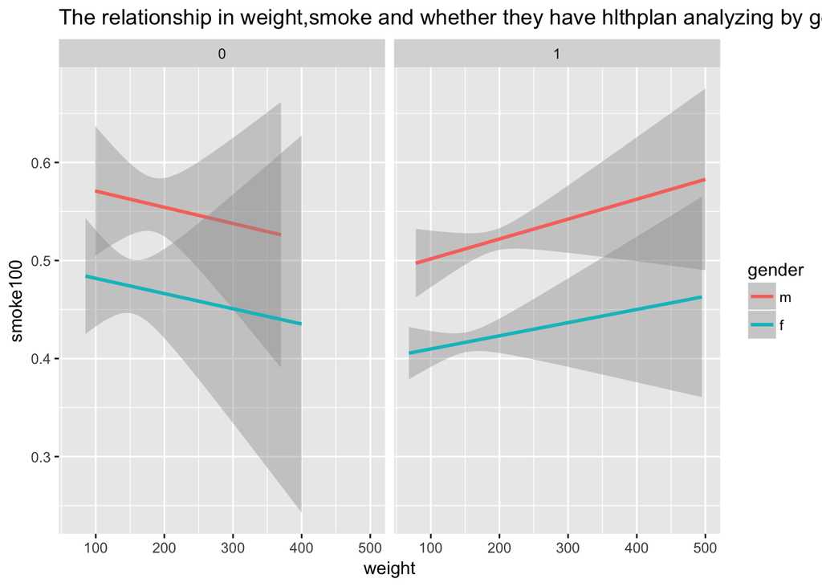

```r
ggplot(data=cdc,mapping=aes(x=weight,y=smoke100,color=gender))+labs(x="weight",y="smoke100",title="The relationship in weight,smoke and whether they have hlthplan analyzing by gender")+geom_smooth(method="gam")+facet_grid(~hlthplan)
```

For non health plan males and females, the light weight people smoke more than heavy weight people, because they think they are healthy and smoking does not matter their health too much, but for heavy weight people, they have fat issue, in this case, they will smoke less to keep their health. For involved in health plan males and females, light weight people are very careful their health issues, so they smoke less and for heavy weight people, they think they have health plan, and if they have health issues, the insurance could cover a lot of for them. They do not pay attention to their health carefully. Females are always smoke less than males.

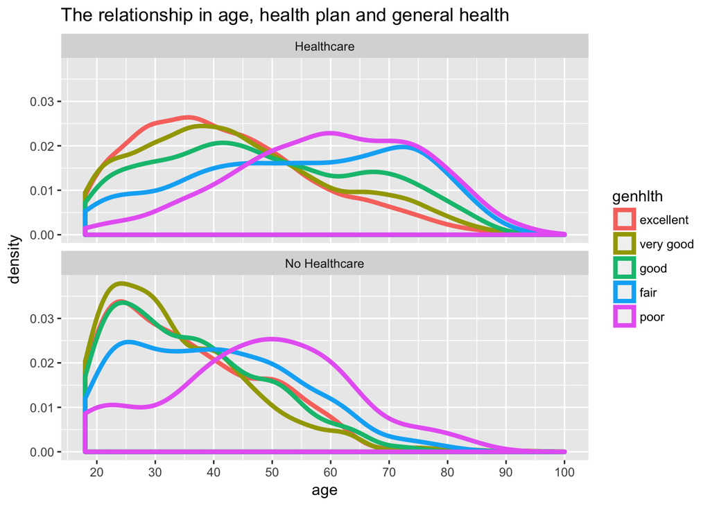

```r
cdc %>%
  ggplot(aes(x=age, color = genhlth)) +
  geom_density(size = 1.5) +
  facet_wrap(~ifelse(hlthplan,"Healthcare", "No Healthcare"), ncol = 1) +
  labs(title="The relationship in age, health plan and general health") +
  scale_x_continuous(limits = c(18,100), breaks=seq(0,100,10)) +
  coord_cartesian(xlim = c(18, 100))
```

This graph reveals many things about the distribution of general health. For one we can see that general health declines as people age (excellent, very good, good, and fair healths decline while poor increases). However, there is a turning point in age where the majority go from fair or better health to poor health. Without healthcare this happens at ~40 years old. With healthcare this is delayed until ~50 years old. Similarly the quality of health falls off much less sharpely with a healthplan with some people in excellent health into their 80s (albiet a miniority), whereas it appears almost no-one maintains excellent health past 70 without a health plan. Some of this may be attributed to people simply switching to health plans as they get older, opting out of one only while they are young. However, we can also see that younger people with a health plan are generally healthier than those without one.

## Results

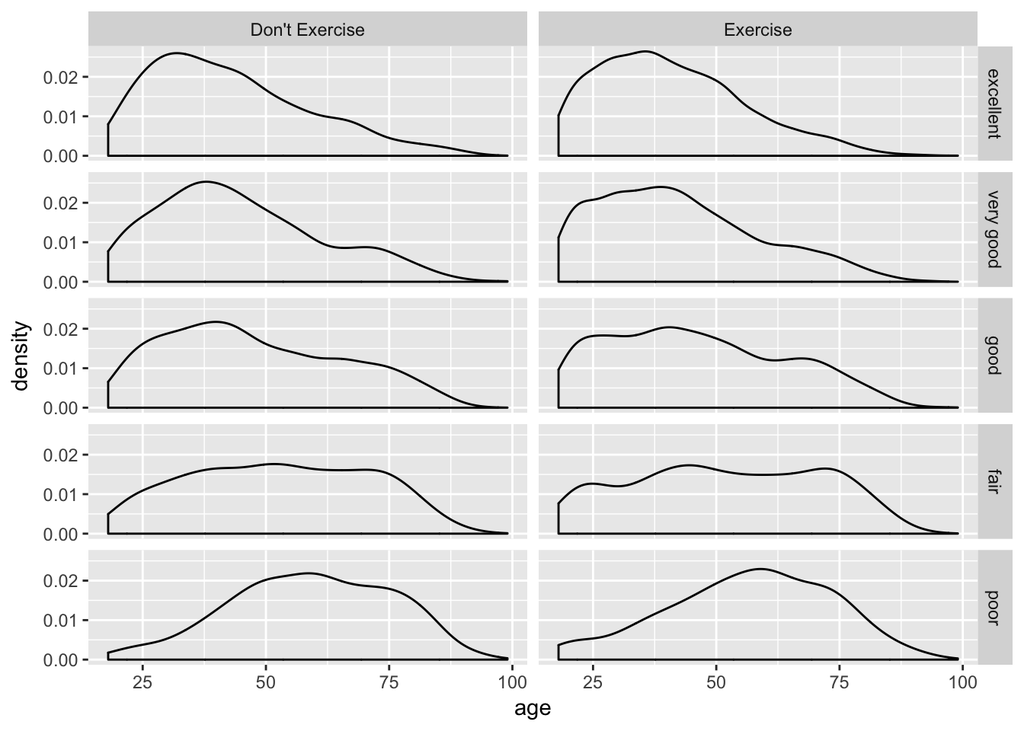

```r
ggplot(data=cdc)+geom_density(aes(age))+facet_grid(genhlth~ifelse(exerany, "Exercise", "Don't Exercise"))
```

## Contributions

Sarah: I created a set of boxplots that showed the relationships between general health and weight, separating the results between males and females, in order to try determine how weight might affect general health.

Will: I have investigated the relationship between weight and smoke. For people who have health plan, the heavy weight people smoke more than light weight people, but for people who don’v have the health plan, it is opposite.

Derek: I worked on a density plot that shows the distribution of general health across age for those with and without a healthplan. I adjusted the scale of the x-axis to better fit the the data and changed the frequency of ticks to give better visual delination of ages. I also specifically wrapped the facets vertically so that it its easier to line up the age on the graphs.